# DC Power estimation

This notebook introduces some tools to model the AC power production of a PV installation.

It is broken down into three parts:

1. **Data visualization**: Exploration of weather data
2. **POA irradiance, temperature, and Power modeling**: Estimation temperature/AC power and comparison to real values.
3. **Performance metric**: Calculation of the Performance Ratio and Energy Performance Index

The attendees are very much welcome to modify and create/execute some new notebook cells to explore data and try out new methods.

**Make sure to manually execute the cells (ctrl + enter) yourself one by one**

The measured data has been downloaded from the Scenario S1, Alburquerque USA, of the PVPMC blind comparison, 2021.

## 1. Data vizualization

```python
# Please execute this cell to import packages
import os
import sys

import pandas as pd
import numpy as np
import matplotlib.pyplot as plt

from pathlib import Path

# Change the directory path to import functions from local modules
if not 'workbookDir' in globals():
    workbookDir = Path(os.getcwd()).parent
print('Work directory: ' + str(workbookDir))
os.chdir(workbookDir)

from src.config import DATA_PATH # Directory ROOT path
from src.utils.helio_fmt import setup_helio_plt
setup_helio_plt() # set plot format and font
```

```
Work directory: C:\Users\MATHIEU\OneDrive - CSTBGroup\Bureau\Code\pvfault_detection_solar_academy
```

## 1.1. In-situ weather data

Below is the weather inputs of the models to estimate the DC production.

```python
# Load weather data: incident irradiation, direct irradiation, temperature, wind
weather_data = pd.read_csv(DATA_PATH / "xtrain.csv", index_col=0)
weather_data.index = pd.to_datetime(weather_data.index)
print(weather_data.head(10))
```

```
                                  ghi        dhi         dni  temp_air  \
2020-01-01 01:00:00-07:00    0.000000   0.000000    0.000000  0.000000
2020-01-01 02:00:00-07:00    0.000000   0.000000    0.000000  0.000000
2020-01-01 03:00:00-07:00    0.000000   0.000000    0.000000  0.000000
2020-01-01 04:00:00-07:00    0.000000   0.000000    0.000000  0.000000
2020-01-01 05:00:00-07:00    0.000000   0.000000    0.000000  0.000000
2020-01-01 06:00:00-07:00    0.000000   0.000000    0.000000  0.000000
2020-01-01 07:00:00-07:00    0.000000   0.000000    0.000000  0.000000
2020-01-01 08:00:00-07:00   40.874978  14.742914  264.832939 -4.737162
2020-01-01 09:00:00-07:00  185.738601  31.546335  754.498236 -3.652383
2020-01-01 10:00:00-07:00  353.666975  40.138926  914.471581 -0.708700

                           wind_speed  sun_azimuth  sun_elevation
2020-01-01 01:00:00-07:00    0.000000    45.887005     -73.699678
2020-01-01 02:00:00-07:00    0.000000    60.330379     -68.551505
2020-01-01 03:00:00-07:00    0.000000    77.923098     -57.096496
2020-01-01 04:00:00-07:00    0.000000    88.482140     -44.932528
2020-01-01 05:00:00-07:00    0.000000    96.723556     -32.690336
2020-01-01 06:00:00-07:00    0.000000   104.269627     -20.636736
2020-01-01 07:00:00-07:00    0.000000   111.925858      -8.981656
2020-01-01 08:00:00-07:00    1.992000   120.264397       2.196798
2020-01-01 09:00:00-07:00    1.803700   129.807715      12.143085
2020-01-01 10:00:00-07:00    2.923567   141.053635      20.729128
```

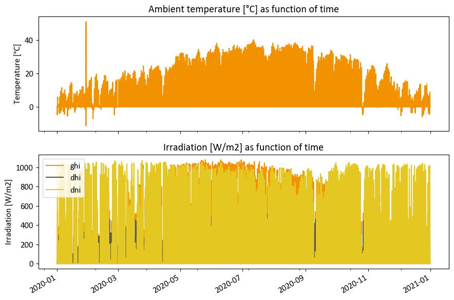

```python
# Make the figure interactive and enable to zoom
#%matplotlib widget
# If the widget does not work, the line below switches to a regular figure
%matplotlib inline

fig, (ax1, ax2) = plt.subplots(2, 1, figsize=(9,6), sharex=True)
weather_data["temp_air"].plot(ax=ax1, title="Ambient temperature [°C] as function of time",ylabel="Temperature [°C]")
meteo_plot = weather_data[["ghi","dhi", "dni"]]
meteo_plot.plot(ax=ax2, title="Irradiation [W/m2] as function of time",ylabel="Irradiation [W/m2]")
plt.tight_layout()
```

## 2. DC power estimation

1. Modeling the POA irradiance.
2. Modeling the module cell temperature.
3. Modeling the installation power production.
4. Modeling the installation inverter efficiency.

### 2.1. POA irradiance

```python
# Installation orientation
beta = 35 # tilt [°]
azimuth = 180 # azimuth [°]
rho = 0.2
```

## Exercice

Calculate the POA irradiance with the no-shading/isotropic assumption as introduced in the notebook "python_intro_poa"

```python
# The lazy way with the pvlib package
from pvlib.irradiance import get_total_irradiance

# Notice it takes degrees as inputs
poa_data = get_total_irradiance(beta, azimuth, 90-weather_data["sun_elevation"], weather_data["sun_azimuth"],
                                weather_data["dni"], weather_data["ghi"], weather_data["dhi"], albedo=rho)
poa_data.head(12)
```

|  | poa_global | poa_direct | poa_diffuse | poa_sky_diffuse | poa_ground_diffuse |
| --- | --- | --- | --- | --- | --- |
| 2020-01-01 01:00:00-07:00 | 0.000000 | 0.000000 | 0.000000 | 0.000000 | 0.000000 |
| 2020-01-01 02:00:00-07:00 | 0.000000 | 0.000000 | 0.000000 | 0.000000 | 0.000000 |
| 2020-01-01 03:00:00-07:00 | 0.000000 | 0.000000 | 0.000000 | 0.000000 | 0.000000 |
| 2020-01-01 04:00:00-07:00 | 0.000000 | 0.000000 | 0.000000 | 0.000000 | 0.000000 |
| 2020-01-01 05:00:00-07:00 | 0.000000 | 0.000000 | 0.000000 | 0.000000 | 0.000000 |
| 2020-01-01 06:00:00-07:00 | 0.000000 | 0.000000 | 0.000000 | 0.000000 | 0.000000 |
| 2020-01-01 07:00:00-07:00 | 0.000000 | 0.000000 | 0.000000 | 0.000000 | 0.000000 |
| 2020-01-01 08:00:00-07:00 | 98.965639 | 84.816622 | 14.149017 | 13.409801 | 0.739216 |
| 2020-01-01 09:00:00-07:00 | 432.922776 | 400.869941 | 32.052835 | 28.693790 | 3.359045 |
| 2020-01-01 10:00:00-07:00 | 689.575320 | 646.669920 | 42.905400 | 36.509405 | 6.395995 |
| 2020-01-01 11:00:00-07:00 | 866.367474 | 817.084130 | 49.283344 | 40.555180 | 8.728164 |
| 2020-01-01 12:00:00-07:00 | 962.202402 | 912.106861 | 50.095541 | 40.043597 | 10.051944 |

### 2.2. Cell temperature model

The cell temperature can be modeled according to:

- Faiman model
- Ross model

```python
NOCT  = 43 # From datasheet

# Generic coefficients for open-rack PV installation from Faiman study (Faiman, D. (2008). “Assessing the outdoor operating temperature of photovoltaic modules.” Progress in Photovoltaics 16(4): 307-315.)
u_0 = 26.9 # W/(˚C.m2)
u_1 = 6.2 # W.s/(˚C.m3)
```

## Exercice

Calculate the module temperature with the Ross or Faiman model

```python
t_mod = weather_data["temp_air"] + (43-20)/800 * poa_data["poa_global"]
t_mod2 = weather_data["temp_air"] +  poa_data["poa_global"] / (u_0 + u_1 * weather_data["wind_speed"])
```

### 2.3. DC power model

## Exercice

Calculate the DC power with the PVwatts or Huld model

```python
Pdc_0 = 3900 #Wp Nominal power
gamma_pdc= -0.258 / 100 # [-]/°C
```

```python
dc_power = Pdc_0 * poa_data["poa_global"] / 1000 * (1 + gamma_pdc * (t_mod2 - 25))
```

### 2.4. AC power model

## Exercice

Calculate the AC power with the PVWatts inverter model with the below function

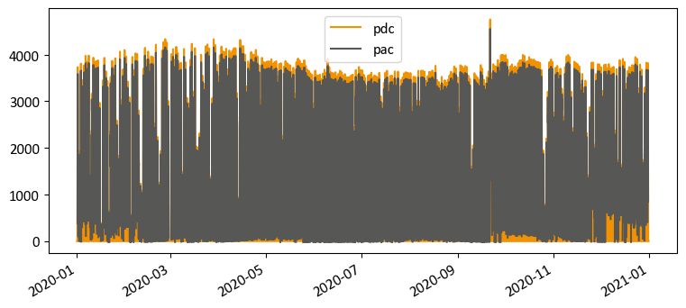

```python
# Adapted from pvlib,
def pvwatts_inverter(pdc, pdc0, eta_inv_nom=0.96, eta_inv_ref=0.9637):

    pac0 = eta_inv_nom * pdc0
    zeta = pdc / pdc0

    # Avoid to divide by 0 for array
    if type(zeta) is float:
        if zeta==0:
            zeta=np.nan
    else:
        zeta[zeta==0] = np.nan

    eta = eta_inv_nom / eta_inv_ref * (-0.0162 * zeta - 0.0059/zeta + 0.9858)

    power_ac = eta * pdc

    return power_ac
ac_power = pvwatts_inverter(dc_power, Pdc_0)

df = pd.DataFrame()
df["pdc"] = dc_power
df["pac"] = ac_power

# Make the figure interactive and enable to zoom
#%matplotlib widget
# If the widget does not work, the line below switches to a regular figure
%matplotlib inline

df.plot(figsize=(9,4))
```

## 3. Performance Ratio calculation

```python
# Load actual data
actual = pd.read_csv(DATA_PATH / "ytrain.csv", index_col=0)
actual.index = pd.to_datetime(actual.index)
print(actual.head(10))
```

```
                                 gpoa      t_mod          pdc
2020-01-01 01:00:00-07:00    0.000000   0.000000     0.000000
2020-01-01 02:00:00-07:00    0.000000   0.000000     0.000000
2020-01-01 03:00:00-07:00    0.000000   0.000000     0.000000
2020-01-01 04:00:00-07:00    0.000000   0.000000     0.000000
2020-01-01 05:00:00-07:00    0.000000   0.000000     0.000000
2020-01-01 06:00:00-07:00    0.000000   0.000000     0.000000
2020-01-01 07:00:00-07:00    0.000000   0.000000     0.000000
2020-01-01 08:00:00-07:00   26.144398  -7.713991   284.904857
2020-01-01 09:00:00-07:00  441.739142   5.177106  1481.974075
2020-01-01 10:00:00-07:00  700.841725  15.212283  2690.471151
```

## Exercice

Calculate the PR and the Energy Performance Index at the DC level

```python
PR = actual["pdc"].sum() / actual["gpoa"].sum() / (Pdc_0/1000)

print(f"PR {round(PR*100,1)} %")
```

```
PR 88.1 %
```

```python
PR_mod = dc_power.sum() / poa_data["poa_global"].sum() / (Pdc_0/1000)
print(f"PR {round(PR_mod*100,1)} %")

EPI = PR/PR_mod

print(f"EPI {round(EPI*100,1)} %")
```

```
PR 96.8 %
EPI 91.0 %
```

### To go further

- What is the accuracy of the values compared to the real values imported below ?

Calculate the Mean Error and Mean Absolute Error

```
Mean Biais: -7.73 W/m²
MAE: 14.42 W/m²
MAE: 2.9 %
```

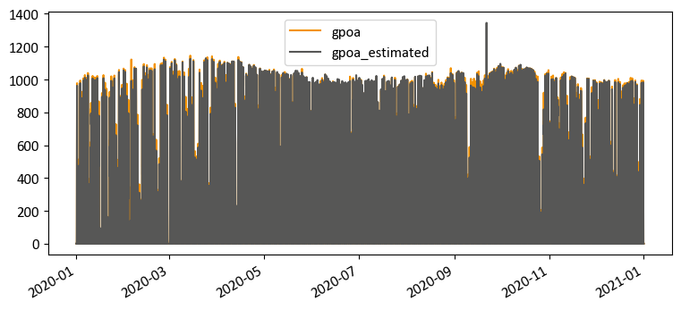

```python
# GPOA accuracy

# Make the figure interactive and enable to zoom
#%matplotlib widget
# If the widget does not work, the line below switches to a regular figure
%matplotlib inline

df = pd.DataFrame()
df["gpoa"] = actual["gpoa"]
df["gpoa_estimated"] = poa_data["poa_global"]

filter = df["gpoa"] >0
print(f'Mean Biais: {round((df.loc[filter, "gpoa_estimated"] -df.loc[filter,"gpoa"]).mean(),2)} W/m²')
print(f'MAE: {round((df.loc[filter, "gpoa_estimated"] -df.loc[filter,"gpoa"]).abs().mean(),2)} W/m²')
print(f'MAE: {round((df.loc[filter, "gpoa_estimated"] -df.loc[filter,"gpoa"]).abs().mean()/df.loc[filter, "gpoa"].mean()*100,2)} %')

df.plot(figsize=(9,4))
```

```
Mean Error: 4.01 °C
MAE: 4.24 °C
```

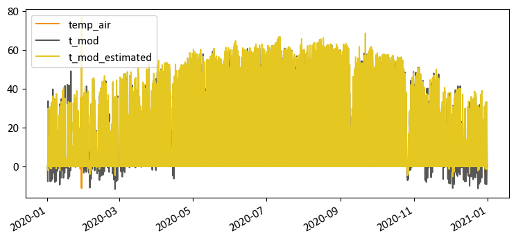

```python
# Tmod accuracy

# Make the figure interactive and enable to zoom
#matplotlib widget
# If the widget does not work, the line below switches to a regular figure
%matplotlib inline

df = pd.DataFrame()
df["temp_air"] = weather_data["temp_air"]
df["t_mod"] = actual["t_mod"]
df["t_mod_estimated"] = t_mod

filter = df["t_mod"] != 0
print(f'Mean Error: {round((df.loc[filter, "t_mod_estimated"] -df.loc[filter,"t_mod"]).mean(),2)} °C')
print(f'MAE: {round((df.loc[filter, "t_mod_estimated"] -df.loc[filter,"t_mod"]).abs().mean(),2)} °C')

df.plot(figsize=(9,4))
```

```
Mean Biais: 99.28 W
MAE: 114.72 W
MAE: 6.51 %
```

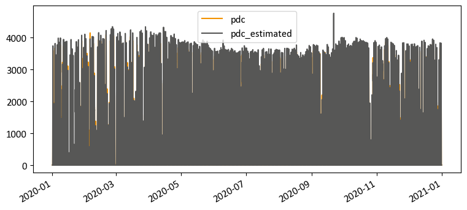

```python
# Make the figure interactive and enable to zoom
#%matplotlib widget
# If the widget does not work, the line below switches to a regular figure
%matplotlib inline

df = pd.DataFrame()
df["pdc"] = actual["pdc"]
df["pdc_estimated"] = dc_power

filter = (df["pdc"] > 1)
print(f'Mean Biais: {round((df.loc[filter, "pdc_estimated"] -df.loc[filter,"pdc"]).mean(),2)} W')
error = df.loc[filter, "pdc_estimated"] -df.loc[filter,"pdc"]
print(f'MAE: {round(error.abs().mean(),2)} W')
print(f'MAE: {round(error.abs().mean()/df.loc[filter, "pdc"].mean()*100,2)} %')

df.plot(figsize=(9,4))
```